# Visualisation de données avec R

## Les thèmes

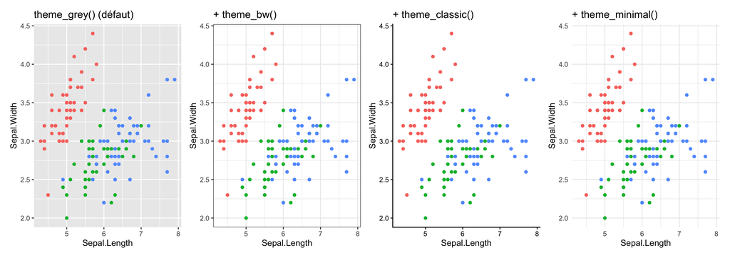

Le thème change l’**apparence** (fond, grille, polices), jamais les données. `theme_set(theme_bw())` en début de script : pour tous les graphiques.

## Titres, légendes, sauvegarde

```r
ggplot(iris, aes(Sepal.Length, Sepal.Width, color = Species)) +
  geom_point() +
  labs(title = "Sépales des iris", x = "Longueur (cm)", y = "Largeur (cm)",
       color = "Espèce", caption = "Données : Fisher (1936)") +  # un titre par aesthetic
  theme_bw() +
  theme(legend.position = "bottom",                                # "none" : pas de légende
        axis.text.x = element_text(angle = 90, hjust = 1))         # étiquettes verticales

ggsave("figures/iris.png", width = 16, height = 10, units = "cm", dpi = 300)  # dernier graphique
ggsave("figures/iris.pdf", plot = p, width = 16, height = 10, units = "cm")
```

- `labs()` : un titre pour chaque *aesthetic* utilisé (`x`, `y`, `color`, `fill`…) ; **toujours** les unités
- `ggsave()` : l’extension choisit le format ; `width`, `height` et `dpi` fixent la **taille réelle** dans l’article
- Un graphique `ggplot2` est un **objet** : `p <- ggplot(...)`, puis `p + theme_bw()`, `ggsave(plot = p)`

## À vous : *limits* ou zoom ?

Les tailles de 50 cellules, dont 3 très grosses (> 200 µm). On écrit :

```r
ggplot(cellules, aes(x = lignee, y = taille)) +
  geom_boxplot() +
  ylim(0, 100)
```

1. Que deviennent les 3 grosses cellules ?
2. La médiane affichée est-elle celle des 50 cellules ?
3. Comment voir le détail sous 100 µm **sans** changer les boxplots ?
1. Elles sont **retirées des données** (`ylim()` = `scale_y_continuous(limits = )`), avec un simple *warning* `Removed 3 rows`
2. Non : médiane, quartiles et moustaches sont calculés sur les **47** restantes
3. `coord_cartesian(ylim = c(0, 100))` : les 3 points sortent du cadre, mais comptent dans le calcul

# Préparer les données

## `ggplot2` attend le format long

Un boxplot des notes **par type d’évaluation** : quelle colonne mettre en `x` ?

grades.tsv : une colonne par évaluation

ID_etuD1D2E1

Etu_19087.594.44

Etu_286.678883.33

Etu_383.337056.67

Aucune : le type d’évaluation est **dans les noms de colonnes**. Il faut une colonne `Type` et une colonne `Note`.

## `ggplot2` attend le format long

une ligne par étudiant × évaluation

ID_etuTypeNote

Etu_1D190

Etu_1D287.5

Etu_1E194.44

Etu_2D186.67

Etu_2D288

Etu_2E183.33

Etu_3D183.33

Etu_3D270

Etu_3E156.67

```r
notes_long <- notes |> pivot_longer(D1:E2, names_to = "Type", values_to = "Note")
ggplot(notes_long, aes(x = Type, y = Note)) + geom_boxplot()
```

## Le format long, puis le graphique

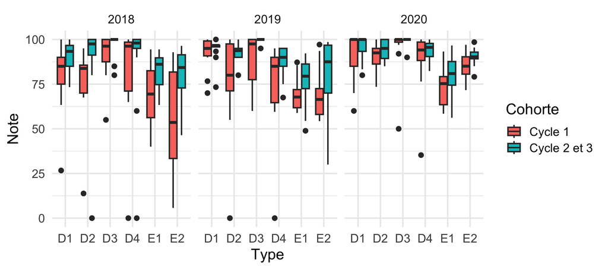

```r
notes_long <- notes |> pivot_longer(D1:E2, names_to = "Type", values_to = "Note")
ggplot(notes_long, aes(x = Type, y = Note, fill = Cohorte)) +
  geom_boxplot() +
  facet_wrap(~ Annee)
```

Une colonne par *aesthetic* : `Type` en x, `Note` en y, `Cohorte` en couleur, `Annee` en facettes.

## L’ordre des catégories

Les évaluations ont eu lieu dans l’ordre D1, D2, **E1**, D3, D4, **E2**. Sur le graphique, elles sont dans l’ordre **alphabétique** :

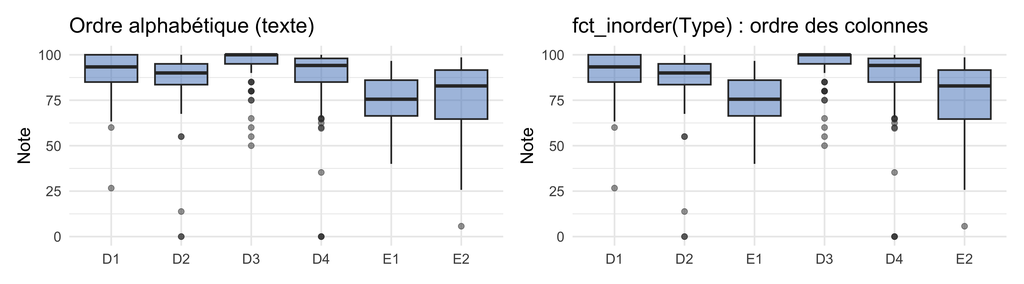

| Fonction (`forcats`) | Ordre obtenu |
| --- | --- |
| `factor(x, levels = c("D1", "D2", "E1"))` | celui qu’on écrit |
| `fct_inorder(x)` | ordre d’apparition dans les données |
| `fct_infreq(x)` | du plus fréquent au moins fréquent (`geom_bar()` trié) |
| `fct_reorder(x, y)` | selon la médiane de `y` (boxplots ou barres triés) |

## Les lignes : l’*aesthetic* `group`

L’évolution de 3 prénoms de garçons (`babynames`) :

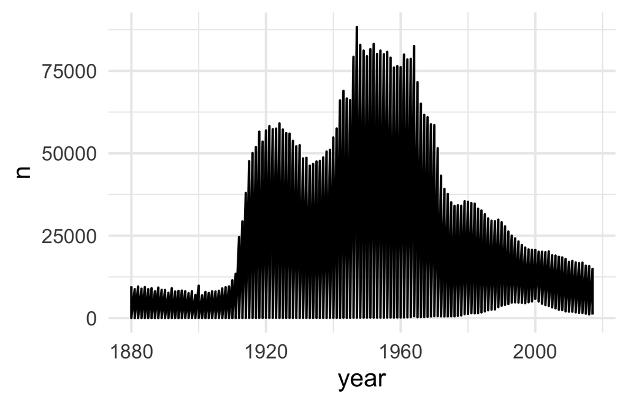

```r
trois |>
  ggplot(aes(year, n)) + geom_line()
```

Une **seule** ligne relie toutes les lignes du tableau dans l’ordre des x : elle zigzague d’un prénom à l’autre chaque année.

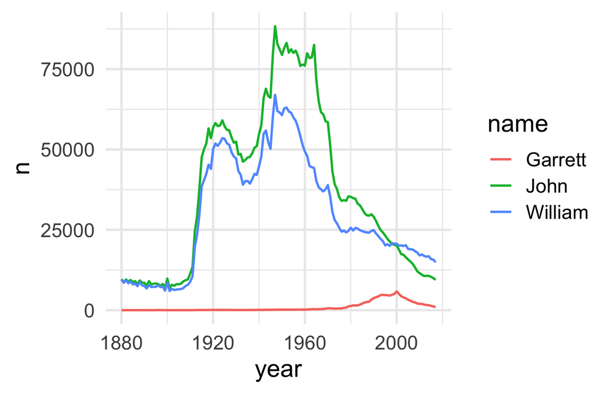

```r
trois |>
  ggplot(aes(year, n, color = name)) + geom_line()
```

`color` (ou `group = name`) découpe les données : **une ligne par prénom**.

## Les `NA` dans un graphique

```r
ggplot(notes_long, aes(Type, Note)) + geom_boxplot()
```

```
#> Warning: Removed 1 row containing non-finite outside the scale range
#> (`stat_boxplot()`).
```

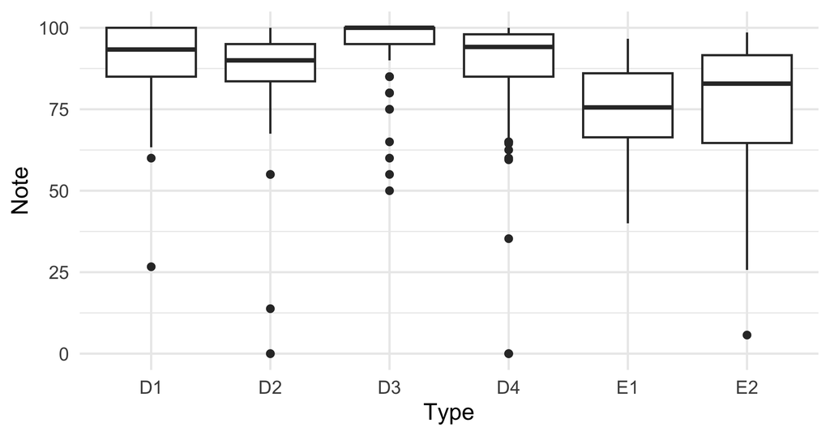

- Une note `D2` manque : `ggplot2` la **retire** et prévient par un *warning*, sans s’arrêter
- Dans un rapport Quarto, les *warnings* sont souvent masqués : comptez les `NA` **avant** de tracer
- Dans une colonne **catégorielle**, `NA` devient une catégorie à part, grise, dans la légende : souvent le signe d’une jointure ratée ou d’une valeur mal saisie

Même logique pour les catégories mal saisies (module 5) : `"Male"` et `"male "` font **deux** couleurs dans la légende. Un graphique est souvent le moyen le plus rapide de les repérer.

## À vous : quel code a produit ce graphique ?

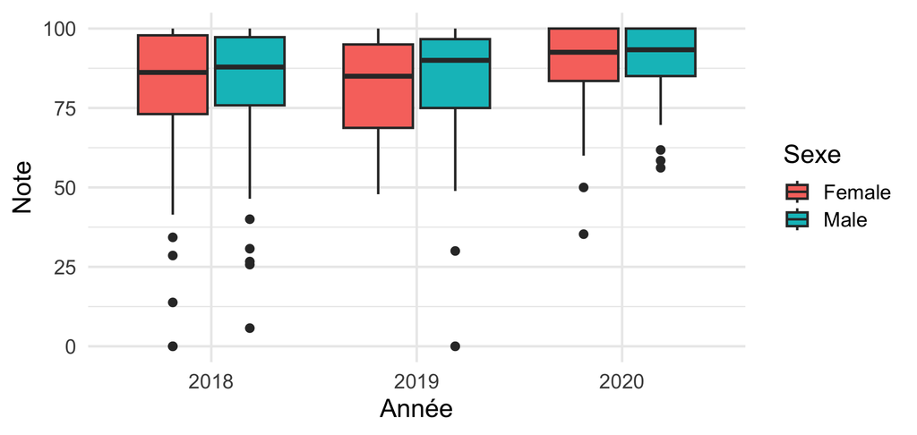

Écrivez le code, à partir de `notes` et `sexes` (une ligne par étudiant : `ID_etu`, `Sex`).

```r
notes |>
  pivot_longer(D1:E2, names_to = "Type", values_to = "Note") |>  # une ligne par note
  left_join(sexes, by = "ID_etu") |>                               # ajouter le sexe
  ggplot(aes(x = factor(Annee), y = Note, fill = Sex)) +           # factor() : 3 groupes
  geom_boxplot() +
  labs(x = "Année", fill = "Sexe")
```

# TP2

# Graphiques de la bioinformatique

## Le boxplot

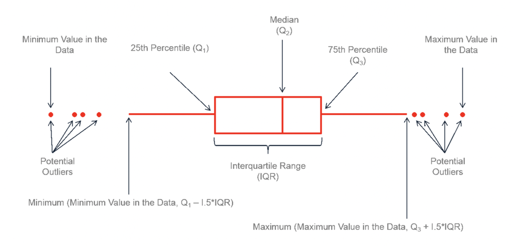

- La boîte : **50 %** des valeurs (du 1<sup>er</sup> au 3<sup>e</sup> quartile) ; le trait : la **médiane**
- Les moustaches : jusqu’à 1.5 × IQR ; au-delà, les points atypiques
- Il ne montre **pas l’effectif** : 4 points et 400 points donnent la même boîte. Ajoutez les points (`geom_jitter()`)

## Les limites du barplot

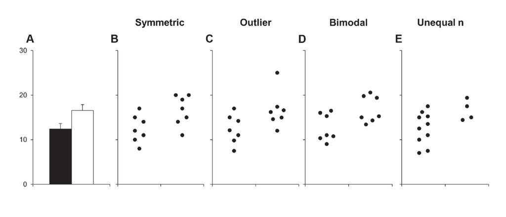

Weissgerber *et al.* (2015). *Beyond bar and line graphs: time for a new data presentation paradigm*. PLoS Biology 13(4): e1002128.

Un barplot convient aux **comptes** et aux **totaux**. Pour une variable continue mesurée sur quelques réplicats, montrez **les points**.

## L’histogramme : la largeur des classes

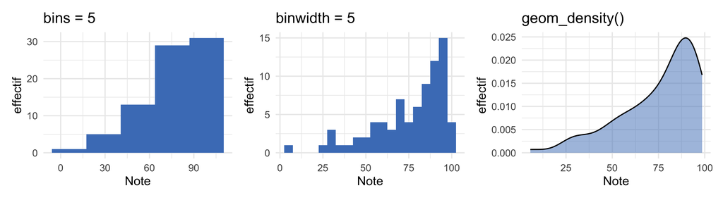

- Les notes de E2 : avec 5 classes, on ne voit pas le groupe d’échecs ; avec des classes de 5 points, il apparaît
- `ggplot2` choisit 30 classes par défaut et le dit : `` `stat_bin()` using `bins = 30`. Pick better value `` : choisissez `bins` ou `binwidth`
- La densité lisse l’histogramme ; elle peut déborder hors des valeurs possibles (au-delà de 100)

## Les résultats d’une expression différentielle

```
#>     gene   baseMean log2FoldChange     pvalue       padj
#> 1 TSPAN6  585.09000        0.13504 4.3732e-01 7.9465e-01
#> 2   TNMD    0.33438       -1.78760 6.5755e-01         NA
#> 3  ICAM1   79.83000        2.87280 2.5421e-18 5.5596e-15
#> 4 CRABP2 1938.70000       -1.41680 6.2468e-27 8.1970e-23
```

`/home/public/visu/de_resultats.csv` : deux conditions, 3 réplicats chacune, 19 320 gènes. Produit par DESeq2 (module 9).

- `log2FoldChange` : l’**ampleur** du changement. +1 = deux fois plus exprimé, −1 = deux fois moins
- `pvalue`, `padj` : la **significativité** ; `padj` est corrigée pour les tests multiples (module 9)
- `padj` vaut `NA` pour les gènes **non testés** (trop peu exprimés) : ici, 6308 gènes

## Le volcano plot

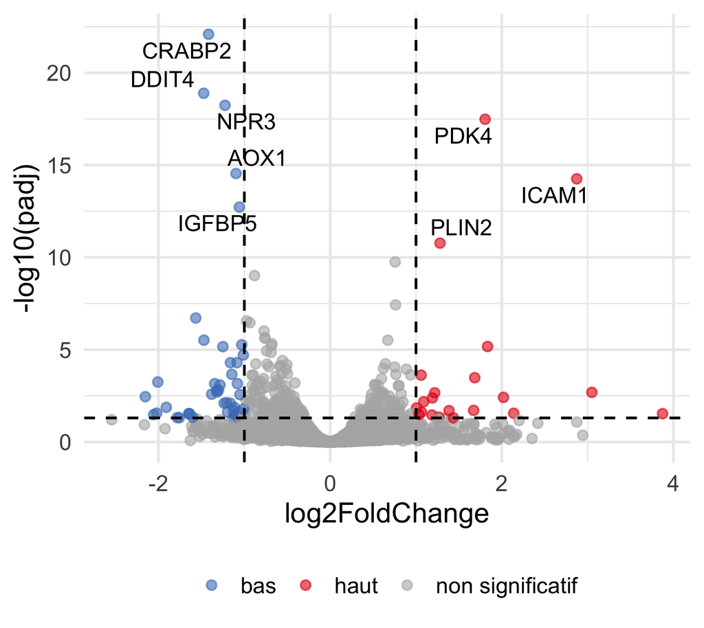

```r
de_v <- de |>
  filter(!is.na(padj)) |>
  mutate(statut = case_when(
    padj < 0.05 & log2FoldChange > 1  ~ "haut",
    padj < 0.05 & log2FoldChange < -1 ~ "bas",
    .default = "non significatif"))

ggplot(de_v, aes(x = log2FoldChange,
                 y = -log10(padj), color = statut)) +
  geom_point(alpha = 0.6) +
  geom_vline(xintercept = c(-1, 1), linetype = 2) +
  geom_hline(yintercept = -log10(0.05),
             linetype = 2) +
  geom_text_repel(data = top, aes(label = gene)) +
  scale_color_manual(values = c(
    haut = "red", bas = "blue",
    `non significatif` = "grey70"))
```

## Lire un volcano plot

- **x** : log2 *fold change*. À droite : plus exprimé ; à gauche : moins exprimé
- **y** : −log10(`padj`). **Plus c’est haut, plus c’est significatif** : `padj` = 0.05 → 1.3 ; 0.001 → 3 ; 10<sup>−20</sup> → 20
- En haut à droite et en haut à gauche : les gènes **à la fois** très changés et significatifs
- Les pointillés : des **seuils choisis** par l’analyste (ici |log2FC| > 1 et `padj` < 0.05). Les changer change la liste des gènes

**Deux couches de données** : `geom_text_repel(data = top, ...)` n’utilise que les 8 gènes de `top`, sur le même graphique. `ggrepel` écarte les étiquettes pour qu’elles ne se chevauchent pas.

« haut » : plus exprimé dans **quelle** condition ? Cela dépend du **niveau de référence** de la comparaison. Vérifiez sur un gène (TP3) ou lisez l’en-tête des résultats (module 9) avant d’écrire « induit ».

## La heatmap

```r
library(pheatmap)
genes <- de |> slice_min(padj, n = 30) |>
  pull(gene)
m <- tpm |>
  filter(gene %in% genes) |>
  column_to_rownames("gene") |>
  as.matrix()
pheatmap(log2(m + 1), scale = "row")
```

- Une **matrice** : un gène par ligne, un échantillon par colonne
- `log2(m + 1)` : les TPM vont de 0 à 20 000 ; le `+ 1` évite `log2(0) = -Inf`
- `scale = "row"` : chaque gène centré-réduit. On compare les **échantillons** entre eux, gène par gène
- Les arbres : un **regroupement** des gènes et des échantillons qui se ressemblent

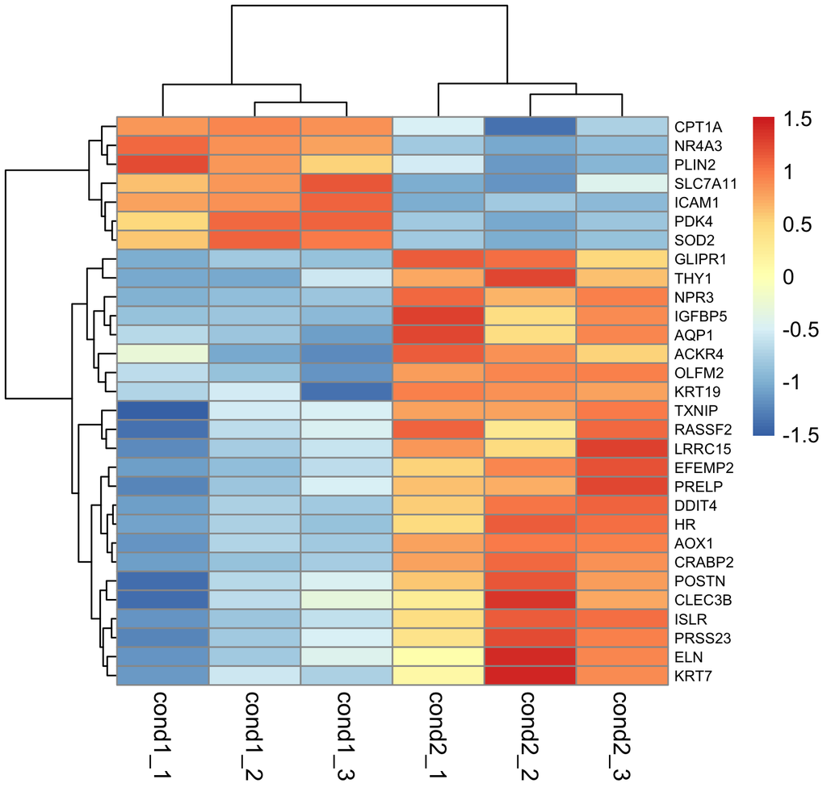

## Sans `scale = "row"`

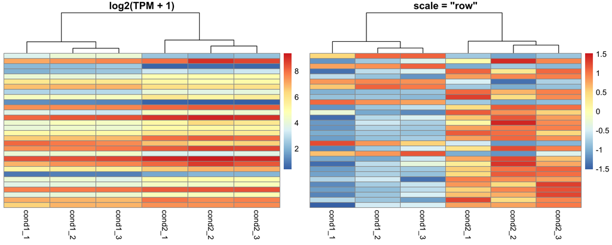

## D’autres graphiques de la bioinformatique

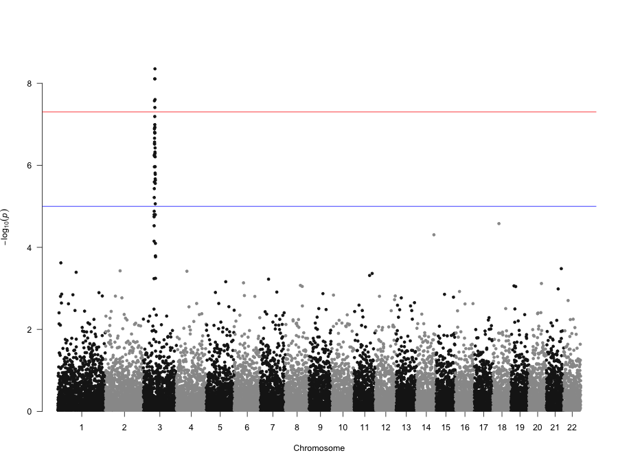

**Manhattan plot** : −log10(p) de chaque SNP le long du génome (études d’association, GWAS)

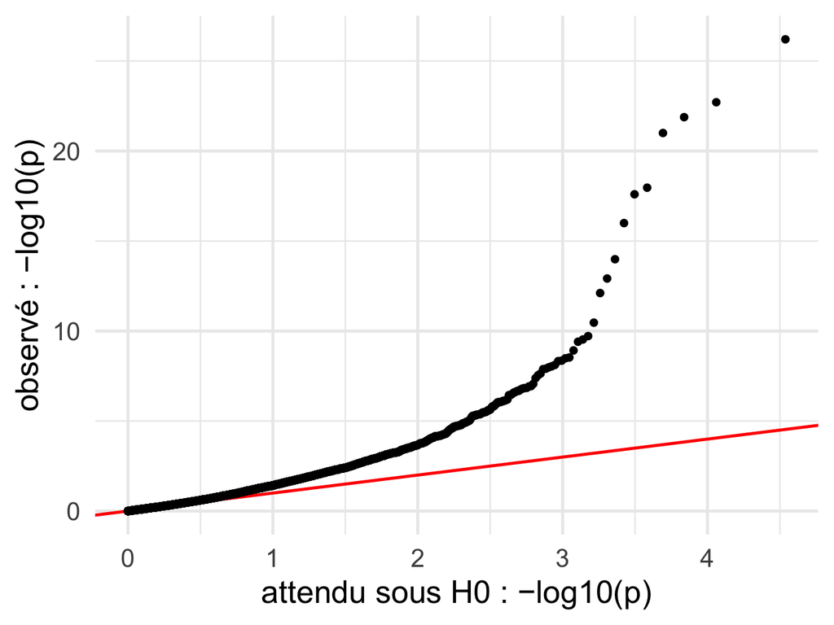

**Q-Q plot** des p-values : sous H0, les points suivent la diagonale ; les gènes qui s’en écartent en haut sont les vrais signaux

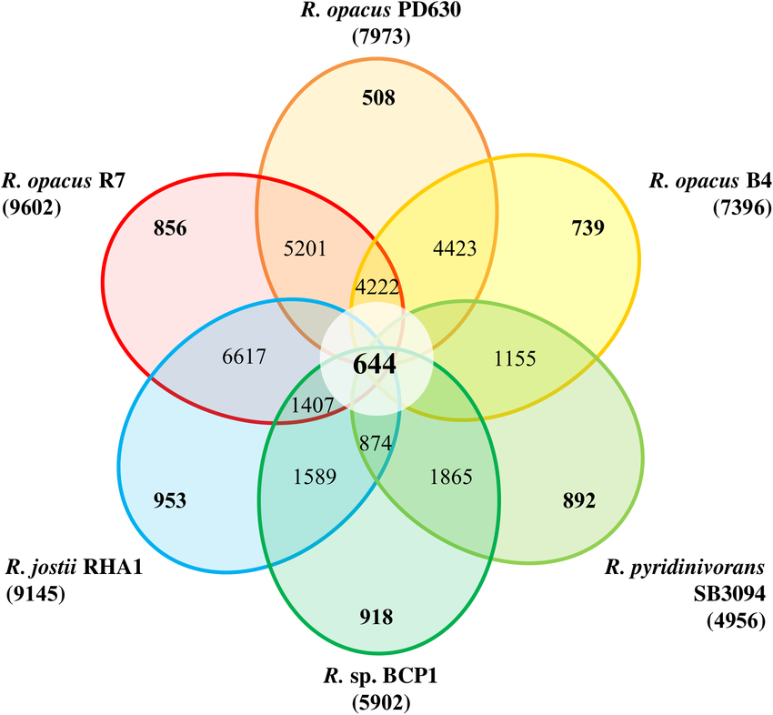

**Diagramme de Venn** (ou UpSet) : les gènes communs à plusieurs listes. Réseaux : module 10

# Bonnes pratiques

## Choisir le graphique

1. **Quelle est la question ?** Comparer des groupes, montrer une distribution, une relation, une évolution
2. **Choisissez le visuel** pour la question et le type de variables, pas pour l’effet
3. **Montrez les données** quand il y en a peu : des points plutôt qu’une barre
4. Donnez le **contexte** : titre, axes avec unités, légende, effectifs, source
5. **Simplifiez** : pas de 3D, pas d’ombres, pas de couleurs qui ne codent rien

## Les erreurs fréquentes

- Axes sans titre ou sans unités
- **Axe tronqué** : un barplot qui ne commence pas à 0
- Des parts qui ne font pas 100 % (*pie chart*)
- Un mauvais type de graphique pour les données
- *Cherry-picking* : ne montrer que les données qui arrangent
- Pas de titre, pas de légende
- **Couleurs** : rouge et vert ensemble (≈ 8 % des hommes ne les distinguent pas) ; préférer `viridis` ou rouge/bleu
- Une **3D** inutile, qui déforme les hauteurs
- Plusieurs variables sans rapport sur un même graphique (deux axes y)
- **Échelles libres** entre facettes sans le signaler

## À vous : qu’est-ce qui ne va pas ?

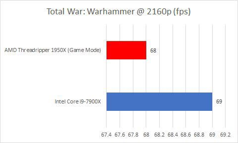

https://getdolphins.com/wp-content/uploads/2018/02/DG5UK_WUAAAVQe5.jpg

- L’axe des x commence à **67.4**, pas à 0 : 68 contre 69 images par seconde, une différence de 1.5 %, devient une barre **2.7 fois** plus longue
- Pour un barplot, la **longueur** de la barre est le message : l’axe doit partir de 0
- Pour des points ou des lignes, un axe qui ne part pas de 0 est acceptable, s’il est clairement gradué

## À vous : qu’est-ce qui ne va pas ?

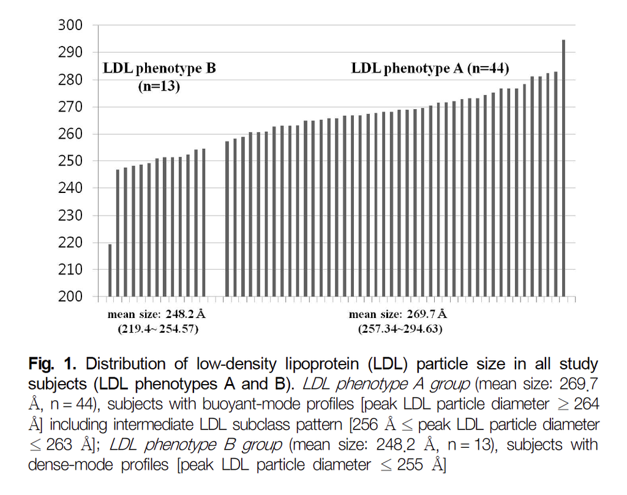

K. Broman, *The top ten worst graphs* : https://www.biostat.wisc.edu/~kbroman/topten_worstgraphs/

## À vous : qu’est-ce qui ne va pas ?

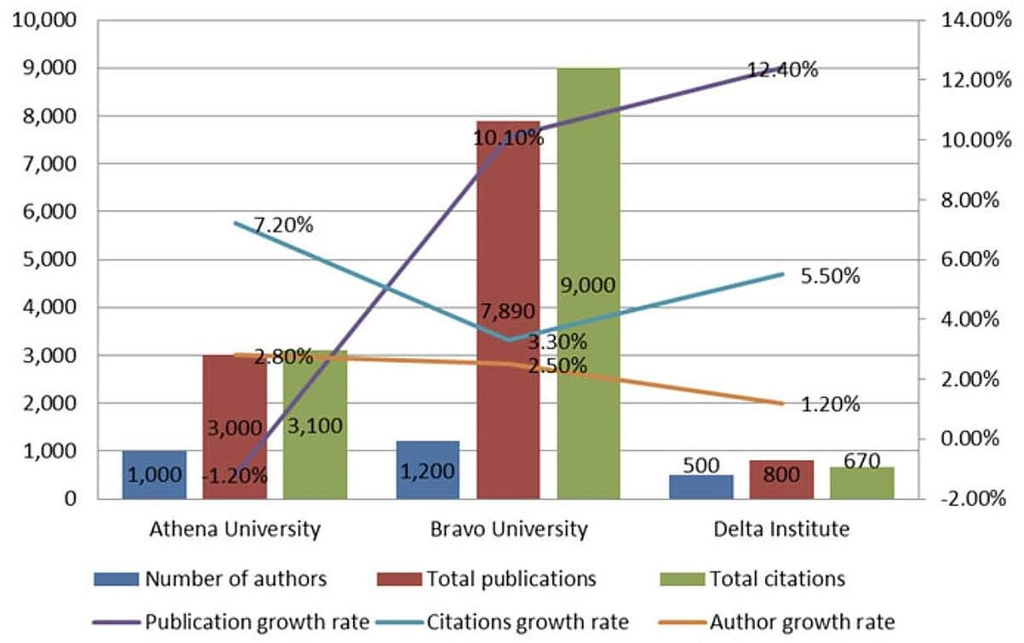

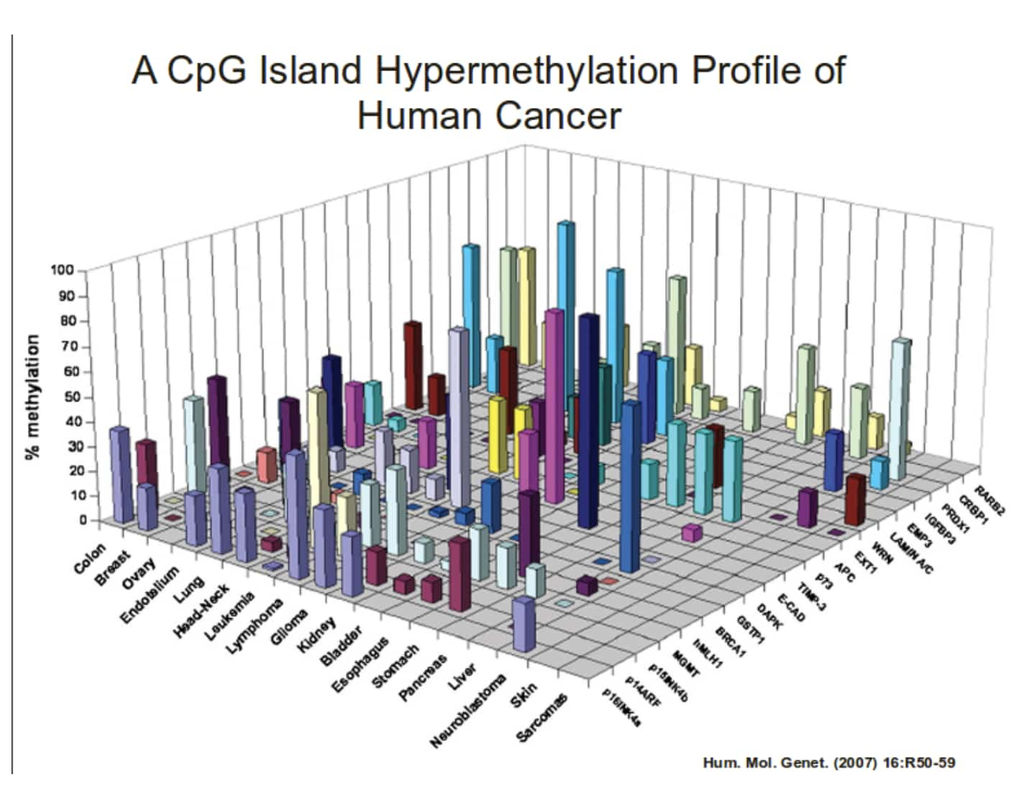

- À gauche : six variables sur un même visuel, avec **deux axes y** : on ne sait plus quelle barre ou quelle ligne lire sur quel axe
- À droite : un tableau tissu × gène en **barres 3D** : des barres en cachent d’autres. Une **heatmap** (couleur = % de méthylation) montrerait tout

# TP3

# Activité : auditer un script

## Auditer un script `ggplot2` généré par IA

> *« À partir de grades.tsv, compare les deux cohortes : (1) la distribution des notes de chaque évaluation, dans l’ordre du trimestre (D1, D2, E1, D3, D4, E2) ; (2) un barplot de la note moyenne de chaque cohorte. Les notes sont sur 100. »*

```r
library(tidyverse)
# Script vérifié : s'exécute sans erreur.
notes <- read_tsv("/home/public/tidyverse/grades.tsv")

notes_long <- notes |>
  pivot_longer(D1:E2, names_to = "Type", values_to = "Note")

# 1. Distribution des notes par évaluation et par cohorte
ggplot(notes_long, aes(x = Type, y = Note, fill = Cohorte)) +
  geom_boxplot() +
  scale_y_continuous(limits = c(50, 100)) +   # les notes sont sur 100
  theme_bw()

# 2. Note moyenne par cohorte
ggplot(notes_long, aes(x = Cohorte, y = Note, fill = "steelblue")) +
  geom_col() +
  labs(y = "Note moyenne")
```

`grades.tsv` (premières lignes)

```
 ID_etu    D1    E2 Annee Cohorte
  Etu_1 90.00 92.86  2018 Cycle 1
  Etu_2 86.67 90.00  2018 Cycle 1
  Etu_3 83.33 30.71  2018 Cycle 1
  Etu_4 83.33 82.86  2018 Cycle 1
```

Effectifs

```
79 étudiants, 474 notes, 1 NA
```

## Auditer : la démarche

**Le script s’exécute sans erreur. Au moins trois de ses graphiques ou de ses détails sont pourtant faux.**

1. **Lire sans exécuter** : que fait réellement chaque ligne ? Lesquelles sont suspectes ?
2. **Vérifier dans RStudio** : lire **tous** les messages, les **axes** et les **légendes**, et refaire les calculs avec `summarise()`
3. **Corriger** et commenter chaque correction

Indices : relisez la demande (l’**ordre** des évaluations, ce qu’est une **moyenne**), lisez les *warnings*, et regardez les valeurs sur l’axe y. Certaines lignes sont correctes : ne corrigez pas ce qui fonctionne.

## Ressources

- *R for Data Science* (2<sup>e</sup> éd., H. Wickham, M. Çetinkaya-Rundel, G. Grolemund) : https://r4ds.hadley.nz, chapitres 1, 9, 10 et 11 (visualisation)
- *ggplot2: Elegant Graphics for Data Analysis* (3<sup>e</sup> éd., H. Wickham) : https://ggplot2-book.org
- *R Graphics Cookbook* (W. Chang) : https://r-graphics.org, une recette par graphique
- *Fundamentals of Data Visualization* (C. Wilke) : https://clauswilke.com/dataviz/, choisir et soigner un graphique
- Aide-mémoire `ggplot2` : https://rstudio.github.io/cheatsheets/data-visualization.pdf
- Galerie : https://r-graph-gallery.com, des centaines de graphiques avec leur code

Données : `iris` (Fisher, 1936), `diamonds` (package `ggplot2`), `babynames` (Social Security Administration, États-Unis ; package `babynames`, H. Wickham), notes anonymisées du cours (`grades.tsv`), résultats DESeq2 d’une expérience RNA-seq (`de_resultats.csv`, `tpm.csv`).